# 白葡萄酒质量分析

## 载入数据

```
##  [1] "X"                    "fixed.acidity"        "volatile.acidity"
##  [4] "citric.acid"          "residual.sugar"       "chlorides"
##  [7] "free.sulfur.dioxide"  "total.sulfur.dioxide" "density"
## [10] "pH"                   "sulphates"            "alcohol"
## [13] "quality"
```

该数据集包含了4898种白葡萄酒，11个量化每种酒化学成分的输入变量（X为索引值），以及一个基于感官数据的输出变量（专家评分）。

## 单因素分析

```
## [1] 4898   13
```

```
## 'data.frame':    4898 obs. of  13 variables:
##  $ X                   : int  1 2 3 4 5 6 7 8 9 10 ...
##  $ fixed.acidity       : num  7 6.3 8.1 7.2 7.2 8.1 6.2 7 6.3 8.1 ...
##  $ volatile.acidity    : num  0.27 0.3 0.28 0.23 0.23 0.28 0.32 0.27 0.3 0.22 ...
##  $ citric.acid         : num  0.36 0.34 0.4 0.32 0.32 0.4 0.16 0.36 0.34 0.43 ...
##  $ residual.sugar      : num  20.7 1.6 6.9 8.5 8.5 6.9 7 20.7 1.6 1.5 ...
##  $ chlorides           : num  0.045 0.049 0.05 0.058 0.058 0.05 0.045 0.045 0.049 0.044 ...
##  $ free.sulfur.dioxide : num  45 14 30 47 47 30 30 45 14 28 ...
##  $ total.sulfur.dioxide: num  170 132 97 186 186 97 136 170 132 129 ...
##  $ density             : num  1.001 0.994 0.995 0.996 0.996 ...
##  $ pH                  : num  3 3.3 3.26 3.19 3.19 3.26 3.18 3 3.3 3.22 ...
##  $ sulphates           : num  0.45 0.49 0.44 0.4 0.4 0.44 0.47 0.45 0.49 0.45 ...
##  $ alcohol             : num  8.8 9.5 10.1 9.9 9.9 10.1 9.6 8.8 9.5 11 ...
##  $ quality             : int  6 6 6 6 6 6 6 6 6 6 ...
```

```
##        X        fixed.acidity    volatile.acidity  citric.acid
##  Min.   :   1   Min.   : 3.800   Min.   :0.0800   Min.   :0.0000
##  1st Qu.:1225   1st Qu.: 6.300   1st Qu.:0.2100   1st Qu.:0.2700
##  Median :2450   Median : 6.800   Median :0.2600   Median :0.3200
##  Mean   :2450   Mean   : 6.855   Mean   :0.2782   Mean   :0.3342
##  3rd Qu.:3674   3rd Qu.: 7.300   3rd Qu.:0.3200   3rd Qu.:0.3900
##  Max.   :4898   Max.   :14.200   Max.   :1.1000   Max.   :1.6600
##  residual.sugar     chlorides       free.sulfur.dioxide
##  Min.   : 0.600   Min.   :0.00900   Min.   :  2.00
##  1st Qu.: 1.700   1st Qu.:0.03600   1st Qu.: 23.00
##  Median : 5.200   Median :0.04300   Median : 34.00
##  Mean   : 6.391   Mean   :0.04577   Mean   : 35.31
##  3rd Qu.: 9.900   3rd Qu.:0.05000   3rd Qu.: 46.00
##  Max.   :65.800   Max.   :0.34600   Max.   :289.00
##  total.sulfur.dioxide    density             pH          sulphates
##  Min.   :  9.0        Min.   :0.9871   Min.   :2.720   Min.   :0.2200
##  1st Qu.:108.0        1st Qu.:0.9917   1st Qu.:3.090   1st Qu.:0.4100
##  Median :134.0        Median :0.9937   Median :3.180   Median :0.4700
##  Mean   :138.4        Mean   :0.9940   Mean   :3.188   Mean   :0.4898
##  3rd Qu.:167.0        3rd Qu.:0.9961   3rd Qu.:3.280   3rd Qu.:0.5500
##  Max.   :440.0        Max.   :1.0390   Max.   :3.820   Max.   :1.0800
##     alcohol         quality
##  Min.   : 8.00   Min.   :3.000
##  1st Qu.: 9.50   1st Qu.:5.000
##  Median :10.40   Median :6.000
##  Mean   :10.51   Mean   :5.878
##  3rd Qu.:11.40   3rd Qu.:6.000
##  Max.   :14.20   Max.   :9.000
```

本数据包括1列索引，12个变量，4898个观测值。

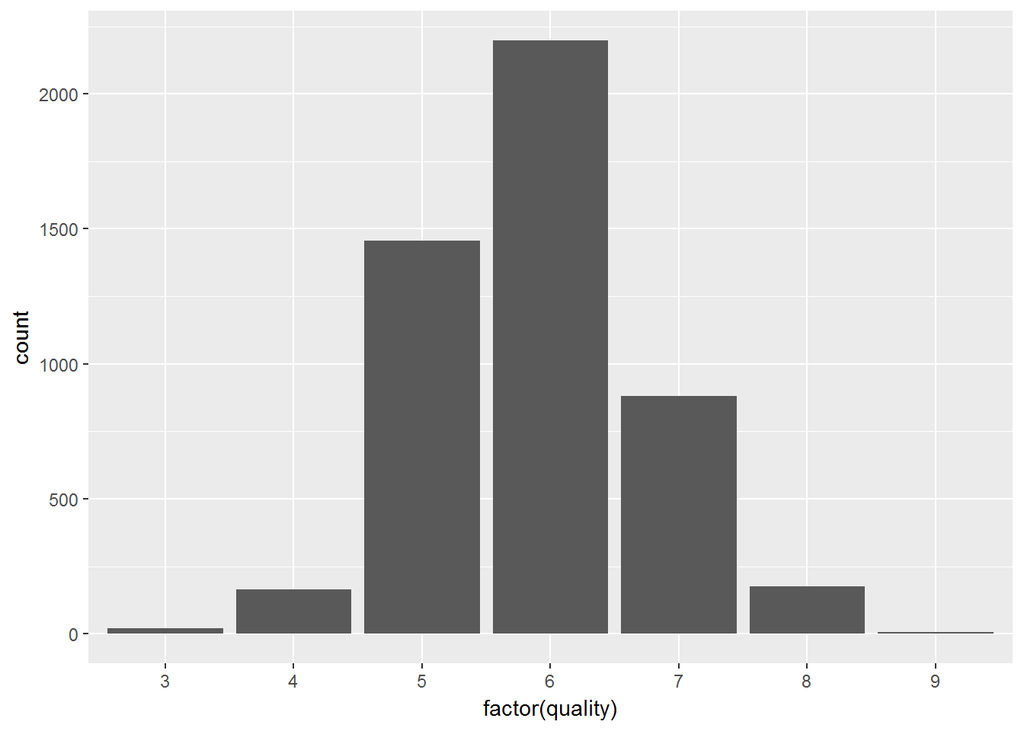

```
##
##    3    4    5    6    7    8    9
##   20  163 1457 2198  880  175    5
```

观察质量评分的结果分布，图形呈现单峰型,评分6呈现最大值即出现了2198次。高评分与低评分均出现较少（每个专家将葡萄酒的品质分为0（非常差）和10（非常优秀）），为探索此白葡萄酒偏好结果需要进一步研究其它变量对质量评分的影响。

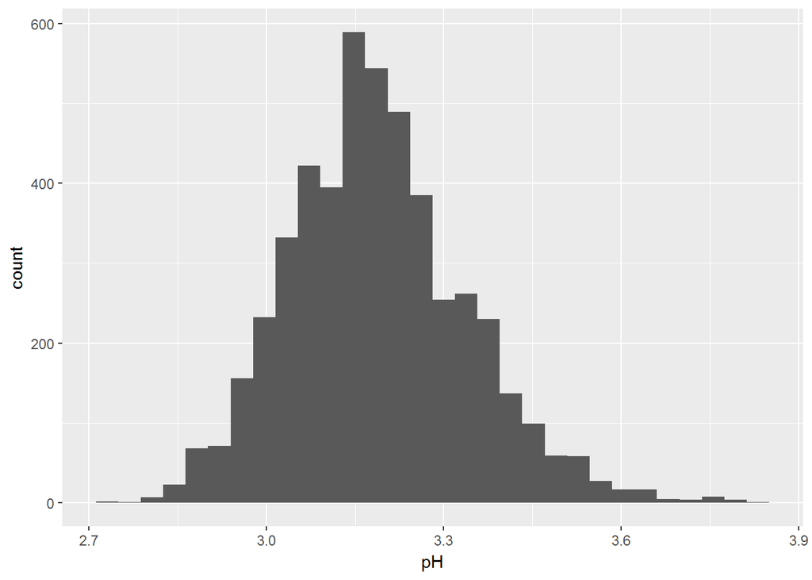

```
##
## 2.72 2.74 2.77 2.79  2.8 2.82 2.83 2.84 2.85 2.86 2.87 2.88 2.89  2.9 2.91
##    1    1    1    3    3    1    4    1    9    9    9   11   17   31   15
## 2.92 2.93 2.94 2.95 2.96 2.97 2.98 2.99    3 3.01 3.02 3.03 3.04 3.05 3.06
##   18   38   35   26   63   32   41   68   74   49   68   78   97   89  115
## 3.07 3.08 3.09  3.1 3.11 3.12 3.13 3.14 3.15 3.16 3.17 3.18 3.19  3.2 3.21
##   79  136   92  135  126  134  117  172  136  164  124  138  145  137   95
## 3.22 3.23 3.24 3.25 3.26 3.27 3.28 3.29  3.3 3.31 3.32 3.33 3.34 3.35 3.36
##  146  116  132  114   96   88   87   82   93   79   86   49   79   48   83
## 3.37 3.38 3.39  3.4 3.41 3.42 3.43 3.44 3.45 3.46 3.47 3.48 3.49  3.5 3.51
##   49   58   40   39   30   48   20   33   17   28   21   21   23   15   14
## 3.52 3.53 3.54 3.55 3.56 3.57 3.58 3.59  3.6 3.61 3.62 3.63 3.64 3.65 3.66
##   17   13   14    9    8    5    5    6    7    3    1    6    2    4    5
## 3.67 3.68 3.69  3.7 3.72 3.74 3.75 3.76 3.77 3.79  3.8 3.81 3.82
##    1    2    2    1    3    2    2    2    2    1    2    1    1
```

```
##    Min. 1st Qu.  Median    Mean 3rd Qu.    Max.
##   2.720   3.090   3.180   3.188   3.280   3.820
```

大多数葡萄酒的pH值在3-4之间，与质量评分类似呈现单峰性，中位数3.180，平均数3.188。 pH值越低酸度越高，需要进一步了解，与酸度有关的变量是如何变化的。

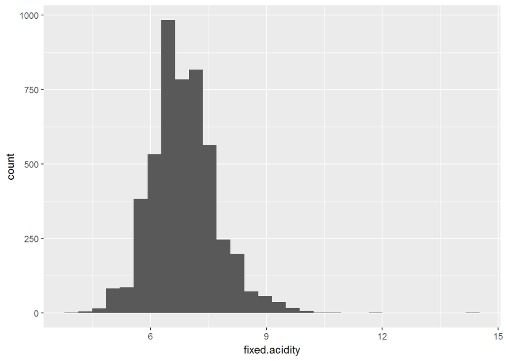

```
##    Min. 1st Qu.  Median    Mean 3rd Qu.    Max.
##   3.800   6.300   6.800   6.855   7.300  14.200
```

```
##
##  3.8  3.9  4.2  4.4  4.5  4.6  4.7  4.8  4.9    5  5.1  5.2  5.3  5.4  5.5
##    1    1    2    3    1    1    5    9    7   24   23   28   27   28   31
##  5.6  5.7  5.8  5.9    6  6.1 6.15  6.2  6.3  6.4 6.45  6.5  6.6  6.7  6.8
##   71   88  121  103  184  155    2  192  188  280    1  225  290  236  308
##  6.9    7  7.1 7.15  7.2  7.3  7.4  7.5  7.6  7.7  7.8  7.9    8  8.1  8.2
##  241  232  200    2  206  178  194  123  153   93   93   74   80   56   56
##  8.3  8.4  8.5  8.6  8.7  8.8  8.9    9  9.1  9.2  9.3  9.4  9.5  9.6  9.7
##   52   35   32   25   15   18   16   17    6   21    3   11    2    5    4
##  9.8  9.9   10 10.2 10.3 10.7 11.8 14.2
##    8    2    3    1    2    2    1    1
```

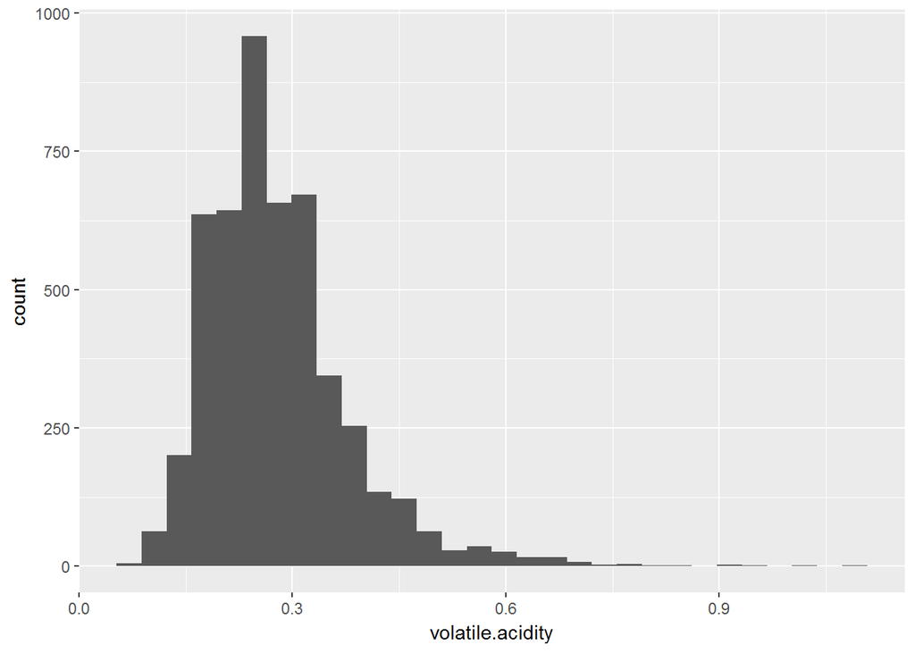

```
##    Min. 1st Qu.  Median    Mean 3rd Qu.    Max.
##  0.0800  0.2100  0.2600  0.2782  0.3200  1.1000
```

```
##
##  0.08 0.085  0.09   0.1 0.105  0.11 0.115  0.12 0.125  0.13 0.135  0.14
##     4     1     1     6     6    13     3    34     3    44     1    56
## 0.145  0.15 0.155  0.16 0.165  0.17 0.175  0.18 0.185  0.19   0.2 0.205
##     4    88     5   141     2   140     1   177     5   170   214     4
##  0.21 0.215  0.22 0.225  0.23 0.235  0.24 0.245  0.25 0.255  0.26 0.265
##   191     1   229     4   216     4   253     4   231    10   240     5
##  0.27 0.275  0.28 0.285  0.29 0.295   0.3 0.305  0.31 0.315  0.32 0.325
##   218     3   263     5   160     3   198     4   148     4   182     2
##  0.33 0.335  0.34 0.345  0.35 0.355  0.36 0.365  0.37 0.375  0.38 0.385
##   134     7   135     9    86     1   104     2    65     2    63     2
##  0.39 0.395   0.4 0.405  0.41 0.415  0.42 0.425  0.43 0.435  0.44 0.445
##    61     2    59     1    54     4    36     2    35     2    46     4
##  0.45 0.455  0.46  0.47 0.475  0.48 0.485  0.49 0.495   0.5  0.51  0.52
##    25     2    30    15     3    17     3    14     2    14    10    10
##  0.53  0.54 0.545  0.55 0.555  0.56  0.57  0.58 0.585  0.59 0.595   0.6
##     8    10     1    14     2     9     4     7     2     4     2     7
##  0.61 0.615  0.62  0.63  0.64  0.65 0.655  0.66  0.67  0.68 0.685  0.69
##     7     4     5     2     7     2     3     4     5     3     1     2
## 0.695 0.705  0.71  0.73  0.74  0.75  0.76  0.78 0.785 0.815  0.85 0.905
##     3     2     1     1     1     1     2     1     1     1     1     1
##  0.91  0.93 0.965 1.005   1.1
##     1     1     1     1     1
```

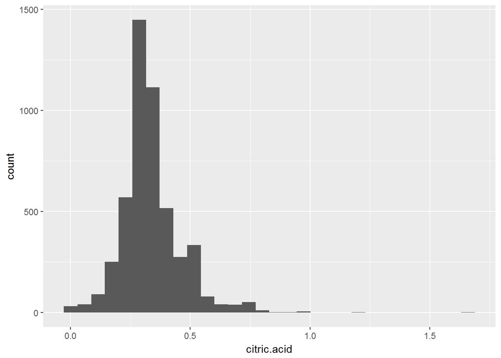

```
##    Min. 1st Qu.  Median    Mean 3rd Qu.    Max.
##  0.0000  0.2700  0.3200  0.3342  0.3900  1.6600
```

```
##
##    0 0.01 0.02 0.03 0.04 0.05 0.06 0.07 0.08 0.09  0.1 0.11 0.12 0.13 0.14
##   19    7    6    2   12    5    6   12    4   12   14    1   19   17   27
## 0.15 0.16 0.17 0.18 0.19  0.2 0.21 0.22 0.23 0.24 0.25 0.26 0.27 0.28 0.29
##   23   33   27   49   48   70   66  104   83  181  136  219  216  282  223
##  0.3 0.31 0.32 0.33 0.34 0.35 0.36 0.37 0.38 0.39  0.4 0.41 0.42 0.43 0.44
##  307  200  257  183  225  137  177  134  122  101  117   82   95   37   63
## 0.45 0.46 0.47 0.48 0.49  0.5 0.51 0.52 0.53 0.54 0.55 0.56 0.57 0.58 0.59
##   46   51   38   39  215   35   25   23   16   19   11   22   13   21    6
##  0.6 0.61 0.62 0.63 0.64 0.65 0.66 0.67 0.68 0.69  0.7 0.71 0.72 0.73 0.74
##    6    9   14    4    6    8    7    7    7    5    3    9    5    5   41
## 0.78 0.79  0.8 0.81 0.82 0.86 0.88 0.91 0.99    1 1.23 1.66
##    2    2    2    2    2    1    1    2    1    5    1    1
```

柠檬酸酸度介于0.27至0.39g/dm^3 之间，中位数 0.32g/dm^3 ，平均值 0.3342g/dm^3 ，近似单峰型，但在 0.49g/dm^3 处出现大量异常值。 总体酸度呢？pH值是否与总酸度有关？ 此处使用固定酸度+挥发酸度+柠檬酸三者之和计算总酸度。

```
##    Min. 1st Qu.  Median    Mean 3rd Qu.    Max.
##   4.130   6.890   7.405   7.467   7.960  14.960
```

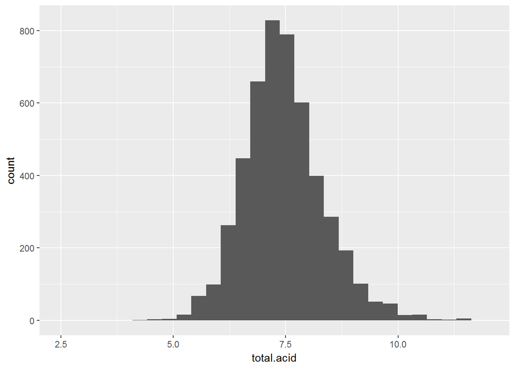

经查阅资料，为了使葡萄酒的口感更加平衡，如果一款葡萄酒酸度不足，会让人觉得平淡乏味；当然如果酸度过高，则会给人一种尖酸锋利的口感。 所以在综合了三种酸度变量后，得到了近似单峰型的总酸度变化，与质量评价和pH变化相似。

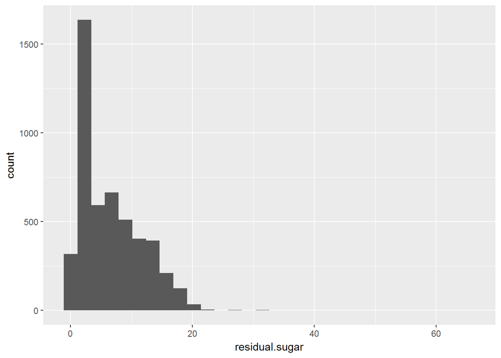

```
##
##   0.6   0.7   0.8   0.9  0.95     1  1.05   1.1  1.15   1.2  1.25   1.3
##     2     7    25    39     4    93     1   146     3   187     3   147
##  1.35   1.4  1.45   1.5  1.55   1.6  1.65   1.7  1.75   1.8  1.85   1.9
##     2   184     4   142     2   165     2    99     1    99     3    59
##  1.95     2  2.05   2.1   2.2  2.25   2.3  2.35   2.4   2.5   2.6  2.65
##     2    79     1    51    56     2    42     1    41    40    33     1
##   2.7   2.8  2.85   2.9     3   3.1  3.15   3.2   3.3   3.4   3.5   3.6
##    38    36     1    25    17    17     1    28    23    13    31    22
##   3.7  3.75   3.8  3.85   3.9  3.95     4   4.1   4.2  4.25   4.3  4.35
##    12     2    21     3    17     3    19    17    31     2    19     1
##   4.4  4.45   4.5  4.55   4.6   4.7  4.75   4.8  4.85   4.9     5   5.1
##    14     3    33     2    40    29     5    38     1    35    43    28
##  5.15   5.2  5.25   5.3  5.35   5.4  5.45   5.5  5.55   5.6   5.7   5.8
##     2    29     4    17     2    23     2    13     1    16    30    23
##  5.85   5.9  5.95     6   6.1   6.2   6.3  6.35   6.4   6.5  6.55   6.6
##     2    19     1    23    21    31    39     1    34    26     1    30
##  6.65   6.7  6.75   6.8  6.85   6.9  6.95     7  7.05   7.1   7.2  7.25
##     3    25     1    28     6    20     1    31     2    36    29     2
##   7.3  7.35   7.4  7.45   7.5   7.6   7.7  7.75   7.8  7.85   7.9  7.95
##    19     2    40     1    30    29    34     2    41     1    32     1
##     8   8.1  8.15   8.2  8.25   8.3   8.4  8.45   8.5  8.55   8.6  8.65
##    32    34     1    36     2    31    13     1    24     1    27     1
##   8.7  8.75   8.8   8.9  8.95     9  9.05   9.1  9.15   9.2  9.25   9.3
##    18     2    22    23     1    18     1    17     2    22     2    11
##   9.4   9.5  9.55   9.6  9.65   9.7   9.8  9.85   9.9    10 10.05  10.1
##    10     9     1    18     4    22    16     3    18    18     3    14
##  10.2  10.3  10.4  10.5 10.55  10.6 10.65  10.7  10.8  10.9    11  11.1
##    23    16    25    16     1    22     1    26    17    11    19    18
##  11.2 11.25  11.3  11.4 11.45  11.5  11.6  11.7 11.75  11.8  11.9 11.95
##    18     2    12    14     1    11    15     8     4    35    16     3
##    12 12.05  12.1 12.15  12.2  12.3  12.4  12.5 12.55  12.6  12.7 12.75
##    16     1    21     4    15    13    19    16     2    16    16     1
##  12.8 12.85  12.9    13  13.1 13.15  13.2  13.3  13.4  13.5 13.55  13.6
##    25     4    25    19    23     1    13    16     7    10     3    12
## 13.65  13.7  13.8  13.9    14 14.05  14.1 14.15  14.2  14.3 14.35  14.4
##     4    21     8    18    16     1     4     1    20    17     3    17
## 14.45  14.5 14.55  14.6  14.7 14.75  14.8  14.9 14.95    15  15.1 15.15
##     3    17     3    13    14     2    12    14     2    13     7     1
##  15.2 15.25  15.3  15.4  15.5 15.55  15.6  15.7 15.75  15.8  15.9    16
##     6     1     9    17    11     6    14     9     1     6     2    10
## 16.05  16.1  16.2  16.3  16.4 16.45  16.5 16.55  16.6 16.65  16.7 16.75
##     6     2     7     7     5     1     3     1     2     5     5     2
##  16.8 16.85  16.9 16.95    17 17.05  17.1  17.2  17.3 17.35  17.4 17.45
##     4     4     3     3     1     1     5     9    14     1     2     2
##  17.5 17.55  17.6  17.7 17.75  17.8 17.85  17.9 17.95    18 18.05  18.1
##     8     3     2     1     4    13     5     2     3     2     3     6
## 18.15  18.2  18.3 18.35  18.4  18.5  18.6 18.75  18.8  18.9 18.95  19.1
##     8     3     2     4     1     1     1     4     3     1     3     1
## 19.25  19.3 19.35  19.4 19.45  19.5  19.6  19.8  19.9 19.95 20.15  20.2
##     3     4     1     2     3     2     1     4     1     3     1     2
##  20.3  20.4  20.7  20.8    22  22.6  23.5 26.05  31.6  65.8
##     1     1     2     2     2     1     1     2     2     1
```

```
##    Min. 1st Qu.  Median    Mean 3rd Qu.    Max.
##   0.600   1.700   5.200   6.391   9.900  65.800
```

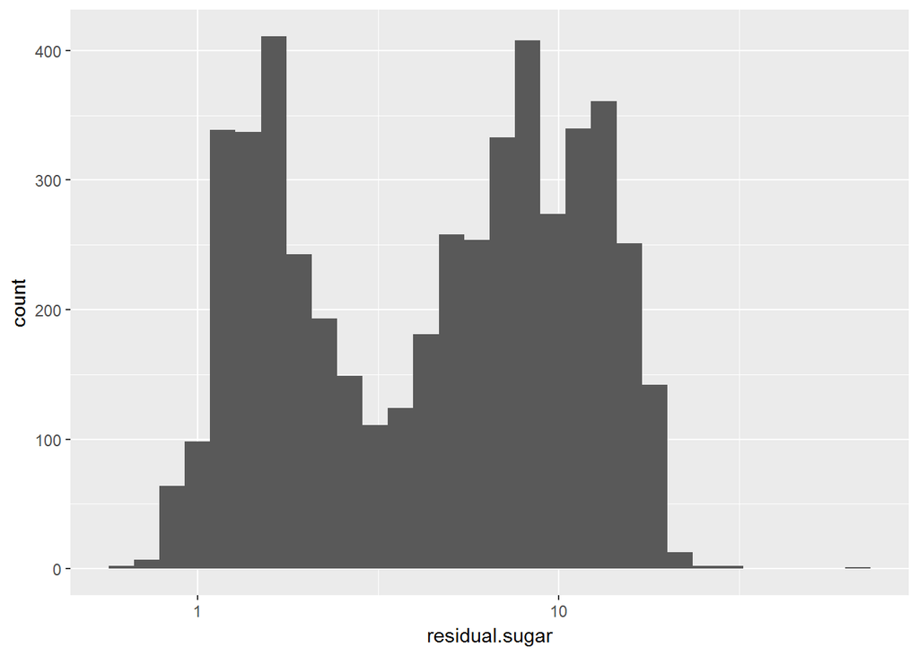

有酸就有甜，研究残糖的直方图发现，分布右倾斜。为判断残糖是否影响白葡萄酒口感，从而影响白葡萄酒质量评价。 经查阅资料发现，残余糖分源自葡萄本身的葡萄糖和果糖，在发酵过程中，没有被转化为酒精的糖分继续留在酒中，即为残糖。其中小于1克/升为干型，大于45克/升的葡萄酒被认为是甜型。样本中仅有一例达到了65.8g/dm^3 ，整体分布在1~16g/dm^3之间。

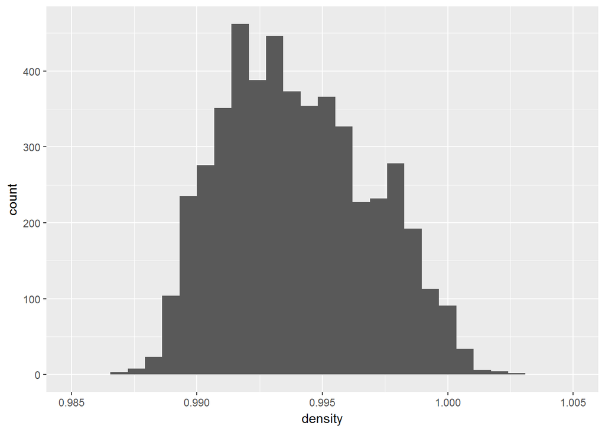

```
##    Min. 1st Qu.  Median    Mean 3rd Qu.    Max.
##  0.9871  0.9917  0.9937  0.9940  0.9961  1.0390
```

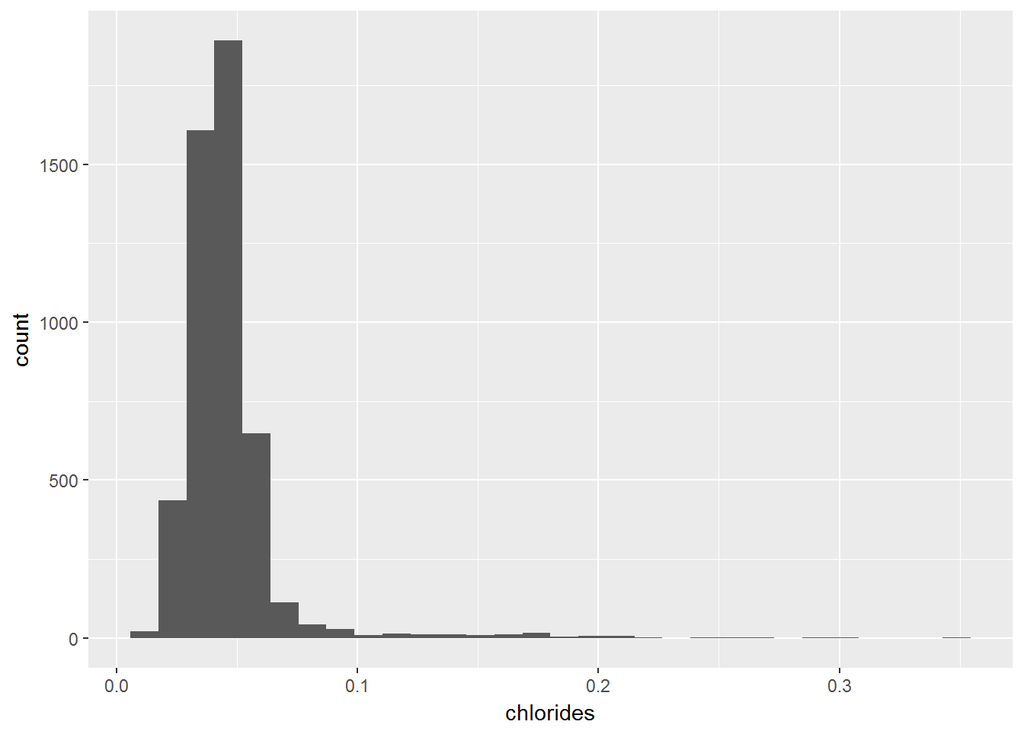

```
##    Min. 1st Qu.  Median    Mean 3rd Qu.    Max.
## 0.00900 0.03600 0.04300 0.04577 0.05000 0.34600
```

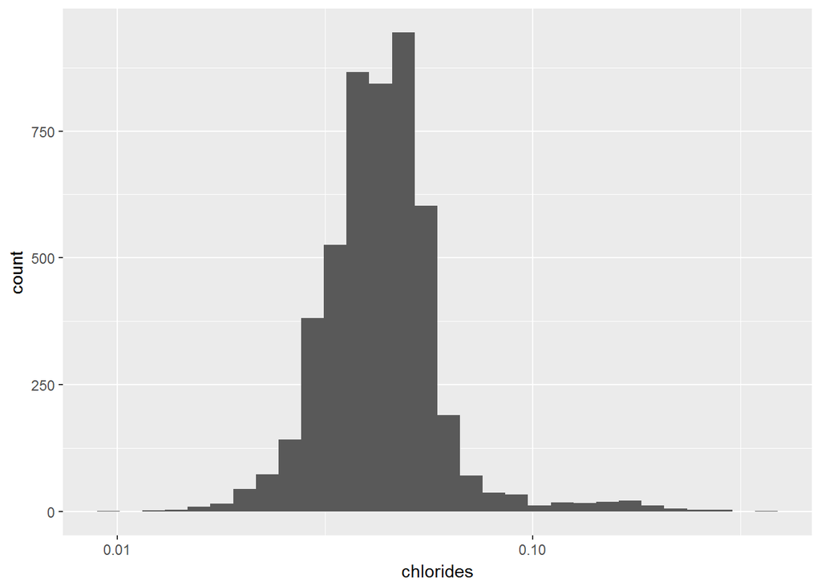

大多数白葡萄酒的氯化物含量介于0.03~0.06g/dm3之间，中位数为0.043g/dm3，平均数为0.046g/dm3。

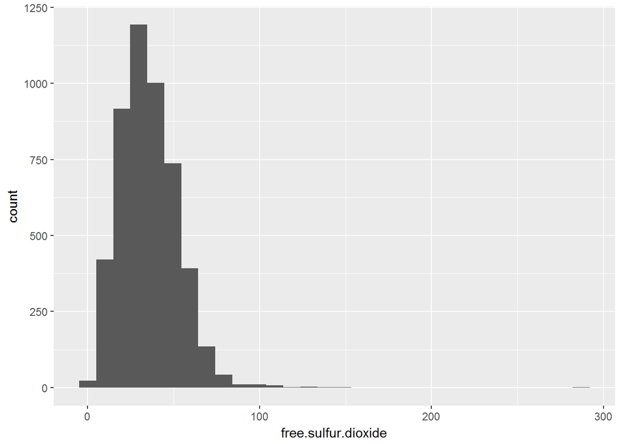

```
##    Min. 1st Qu.  Median    Mean 3rd Qu.    Max.
##    2.00   23.00   34.00   35.31   46.00  289.00
```

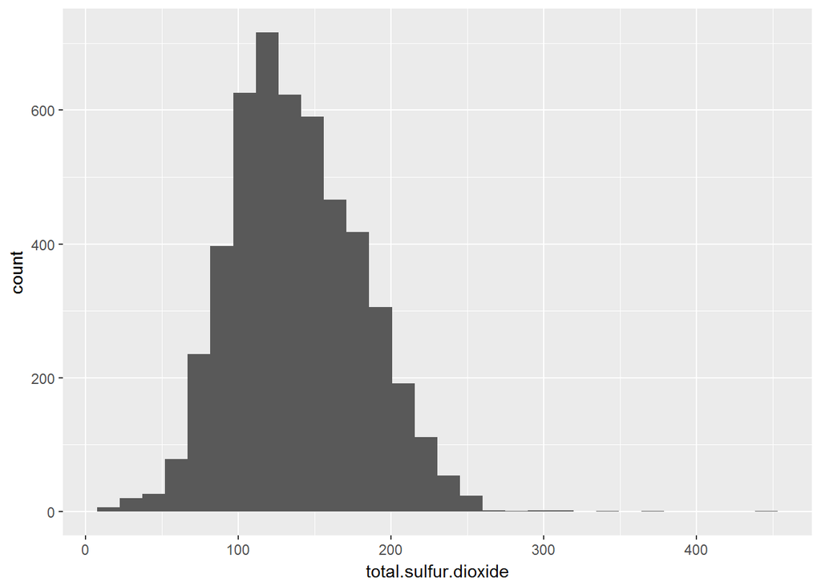

```
##    Min. 1st Qu.  Median    Mean 3rd Qu.    Max.
##     9.0   108.0   134.0   138.4   167.0   440.0
```

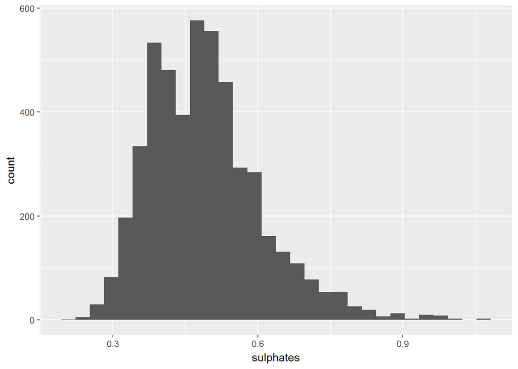

```
##    Min. 1st Qu.  Median    Mean 3rd Qu.    Max.
##  0.2200  0.4100  0.4700  0.4898  0.5500  1.0800
```

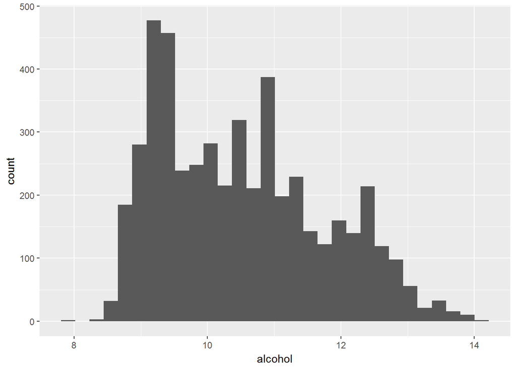

```
##    Min. 1st Qu.  Median    Mean 3rd Qu.    Max.
##    8.00    9.50   10.40   10.51   11.40   14.20
```

```
##
##              9.4              9.5              9.2                9
##              229              228              199              185
##               10             10.5               11             10.4
##              162              160              158              153
##              9.1              9.8             10.8              9.3
##              144              136              135              134
##             10.2              9.6             11.4             10.1
##              130              128              121              114
##             10.6             11.2              9.9              8.8
##              114              112              109              107
##              9.7               12             11.3             10.7
##              105              102              101               96
##              8.9             10.9             11.5             12.2
##               95               88               88               86
##             10.3             11.1             12.5              8.7
##               85               83               83               78
##             12.4             12.6             12.3             11.8
##               68               63               62               60
##             11.7             12.7             12.8             11.9
##               58               56               54               53
##             12.1             11.6             12.9               13
##               51               46               39               36
##              8.6             13.4             13.1             13.2
##               23               20               18               14
##             13.5              8.5             13.6             13.3
##               12                9                9                7
##             13.7               14            11.45              8.4
##                7                5                4                3
## 9.53333333333333            10.15 10.9666666666667 11.3333333333333
##                3                3                3                3
##            12.75             13.9                8             9.55
##                3                3                2                2
## 9.73333333333333 10.1333333333333 10.4666666666667            10.55
##                2                2                2                2
## 10.9333333333333            11.05 11.6333333333333            11.75
##                2                2                2                2
##            11.94            12.15 12.8933333333333             13.8
##                2                2                2                2
## 9.63333333333333             9.75 10.0333333333333 10.5333333333333
##                1                1                1                1
## 10.5666666666667            10.65            10.98 11.0666666666667
##                1                1                1                1
## 11.2666666666667            11.35 11.3666666666667 11.4333333333333
##                1                1                1                1
## 11.4666666666667            11.55            11.65 11.7333333333333
##                1                1                1                1
##            11.85            11.95            12.05 12.0666666666667
##                1                1                1                1
##            12.25 12.3333333333333            13.05 13.1333333333333
##                1                1                1                1
##            13.55            14.05             14.2
##                1                1                1
```

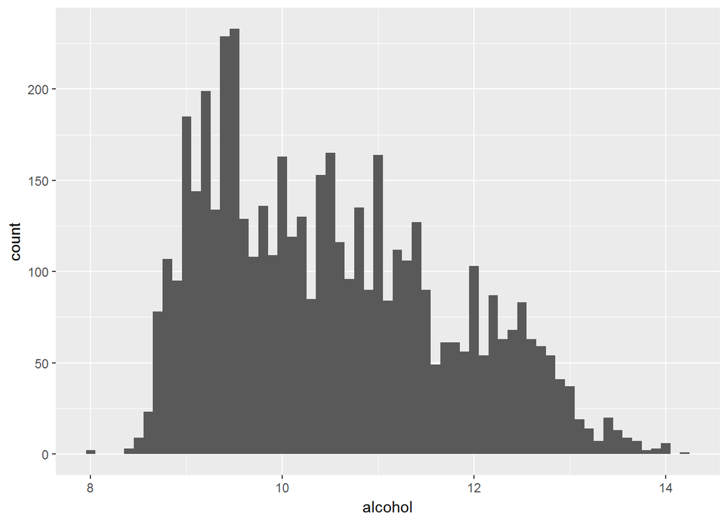

最小的酒精度数是8度，最大的是14.2度，中位数10.4度，均值10.51度。 酒精度数表现呈现右倾斜，暂不清楚酒精度数如何与白葡萄酒质量评价如何挂钩，但白葡萄酒的密度与酒精度可能存在很强的关系。

## 单因素小结

### 该数据集数据结构小结：

在数据集中4898种白葡萄酒，具有11个量化每种酒化学成分的输入变量特征（固定酸度、挥发性酸度、柠檬酸、残糖、氯化物、游离二氧化碳、二氧化硫总量、密度、PH值、硫酸盐、酒精），以及一个基于感官数据的输出变量特征（专家评分），其中质量评分越高白葡萄酒评价越理想。 下一步将研究酸度、pH值和酒精度数对白葡萄酒质量评价的影响。 其他意见： 专家评分分布于3-9分，平均分5.878分，分数越高白葡萄酒质量越理想。 中位pH大小为3.18。 白葡萄酒呈酸性，大多数残糖值经测量小于45克/升。

### 数据集中的主要特征是什么？

数据集的主要特征是酒精度和质量。下一步将在双变量和多变量中进一步探寻酒精度、密度和质量评价间的关系。

### 您是否从数据集中的现有变量创建了任何新变量？

我使用固定酸度、挥发酸度、柠檬酸三者之和为白葡萄酒创建了一个变量。通过将三个变量相加来计算总体酸度。

### 在您调查的功能中，是否有不寻常的分布？

残糖分布呈右倾斜，转换后的残糖分布呈现双峰型。

## 双因素量分析

```
##                      fixed.acidity volatile.acidity  citric.acid
## fixed.acidity           1.00000000      -0.02269729  0.289180698
## volatile.acidity       -0.02269729       1.00000000 -0.149471811
## citric.acid             0.28918070      -0.14947181  1.000000000
## residual.sugar          0.08902070       0.06428606  0.094211624
## chlorides               0.02308564       0.07051157  0.114364448
## free.sulfur.dioxide    -0.04939586      -0.09701194  0.094077221
## total.sulfur.dioxide    0.09106976       0.08926050  0.121130798
## density                 0.26533101       0.02711385  0.149502571
## pH                     -0.42585829      -0.03191537 -0.163748211
## sulphates              -0.01714299      -0.03572815  0.062330940
## alcohol                -0.12088112       0.06771794 -0.075728730
## quality                -0.11366283      -0.19472297 -0.009209091
## total.acid              0.98717874       0.07157062  0.394143356
##                      residual.sugar   chlorides free.sulfur.dioxide
## fixed.acidity            0.08902070  0.02308564       -0.0493958591
## volatile.acidity         0.06428606  0.07051157       -0.0970119393
## citric.acid              0.09421162  0.11436445        0.0940772210
## residual.sugar           1.00000000  0.08868454        0.2990983537
## chlorides                0.08868454  1.00000000        0.1013923521
## free.sulfur.dioxide      0.29909835  0.10139235        1.0000000000
## total.sulfur.dioxide     0.40143931  0.19891030        0.6155009650
## density                  0.83896645  0.25721132        0.2942104109
## pH                      -0.19413345 -0.09043946       -0.0006177961
## sulphates               -0.02666437  0.01676288        0.0592172458
## alcohol                 -0.45063122 -0.36018871       -0.2501039415
## quality                 -0.09757683 -0.20993441        0.0081580671
## total.acid               0.10473749  0.04552987       -0.0451333172
##                      total.sulfur.dioxide     density            pH
## fixed.acidity                 0.091069756  0.26533101 -0.4258582910
## volatile.acidity              0.089260504  0.02711385 -0.0319153683
## citric.acid                   0.121130798  0.14950257 -0.1637482114
## residual.sugar                0.401439311  0.83896645 -0.1941334540
## chlorides                     0.198910300  0.25721132 -0.0904394560
## free.sulfur.dioxide           0.615500965  0.29421041 -0.0006177961
## total.sulfur.dioxide          1.000000000  0.52988132  0.0023209718
## density                       0.529881324  1.00000000 -0.0935914935
## pH                            0.002320972 -0.09359149  1.0000000000
## sulphates                     0.134562367  0.07449315  0.1559514973
## alcohol                      -0.448892102 -0.78013762  0.1214320987
## quality                      -0.174737218 -0.30712331  0.0994272457
## total.acid                    0.113188502  0.27560881 -0.4306513315
##                        sulphates     alcohol      quality  total.acid
## fixed.acidity        -0.01714299 -0.12088112 -0.113662831  0.98717874
## volatile.acidity     -0.03572815  0.06771794 -0.194722969  0.07157062
## citric.acid           0.06233094 -0.07572873 -0.009209091  0.39414336
## residual.sugar       -0.02666437 -0.45063122 -0.097576829  0.10473749
## chlorides             0.01676288 -0.36018871 -0.209934411  0.04552987
## free.sulfur.dioxide   0.05921725 -0.25010394  0.008158067 -0.04513332
## total.sulfur.dioxide  0.13456237 -0.44889210 -0.174737218  0.11318850
## density               0.07449315 -0.78013762 -0.307123313  0.27560881
## pH                    0.15595150  0.12143210  0.099427246 -0.43065133
## sulphates             1.00000000 -0.01743277  0.053677877 -0.01185225
## alcohol              -0.01743277  1.00000000  0.435574715 -0.11751272
## quality               0.05367788  0.43557472  1.000000000 -0.13137721
## total.acid           -0.01185225 -0.11751272 -0.131377207  1.00000000
```

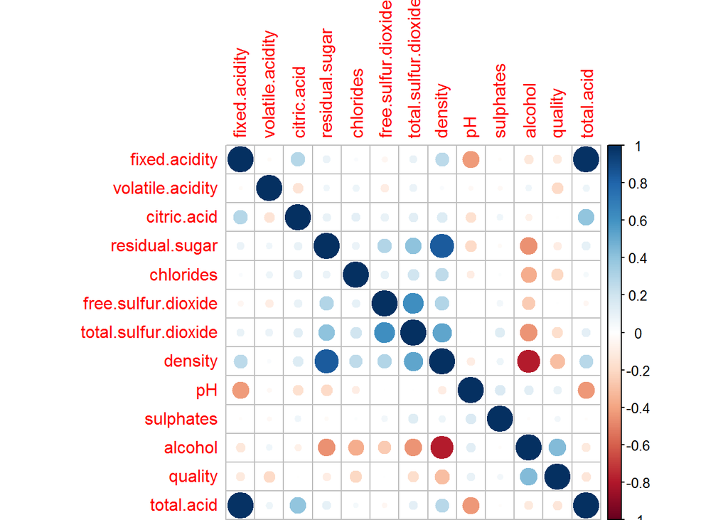

分析各变量间的相关性，与质量相关性最多的是酒精度，其次是密度，pH值与总体酸度相互关联。

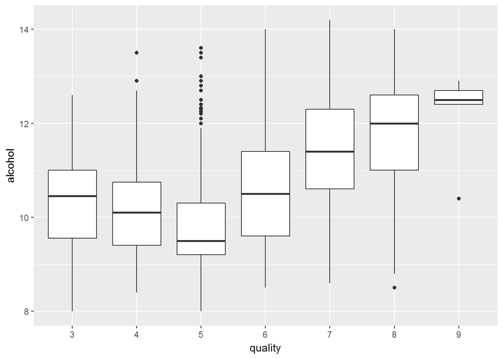

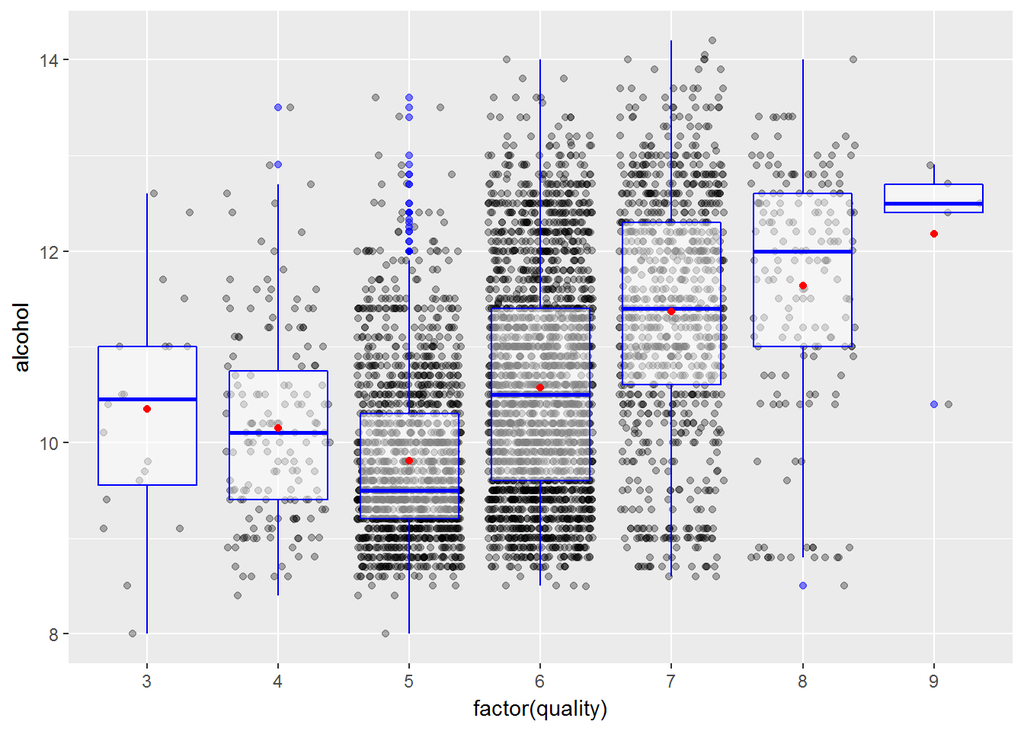

```
## $`3`
##    Min. 1st Qu.  Median    Mean 3rd Qu.    Max.
##    8.00    9.55   10.45   10.34   11.00   12.60
##
## $`4`
##    Min. 1st Qu.  Median    Mean 3rd Qu.    Max.
##    8.40    9.40   10.10   10.15   10.75   13.50
##
## $`5`
##    Min. 1st Qu.  Median    Mean 3rd Qu.    Max.
##   8.000   9.200   9.500   9.809  10.300  13.600
##
## $`6`
##    Min. 1st Qu.  Median    Mean 3rd Qu.    Max.
##    8.50    9.60   10.50   10.58   11.40   14.00
##
## $`7`
##    Min. 1st Qu.  Median    Mean 3rd Qu.    Max.
##    8.60   10.60   11.40   11.37   12.30   14.20
##
## $`8`
##    Min. 1st Qu.  Median    Mean 3rd Qu.    Max.
##    8.50   11.00   12.00   11.64   12.60   14.00
##
## $`9`
##    Min. 1st Qu.  Median    Mean 3rd Qu.    Max.
##   10.40   12.40   12.50   12.18   12.70   12.90
```

首先，从中位数观察酒精度与质量的关系，发现酒精度越高质量越好，呈正相关关系。

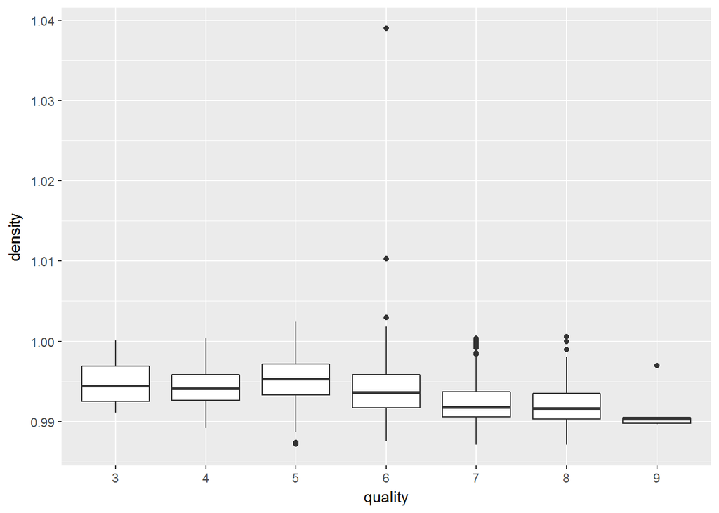

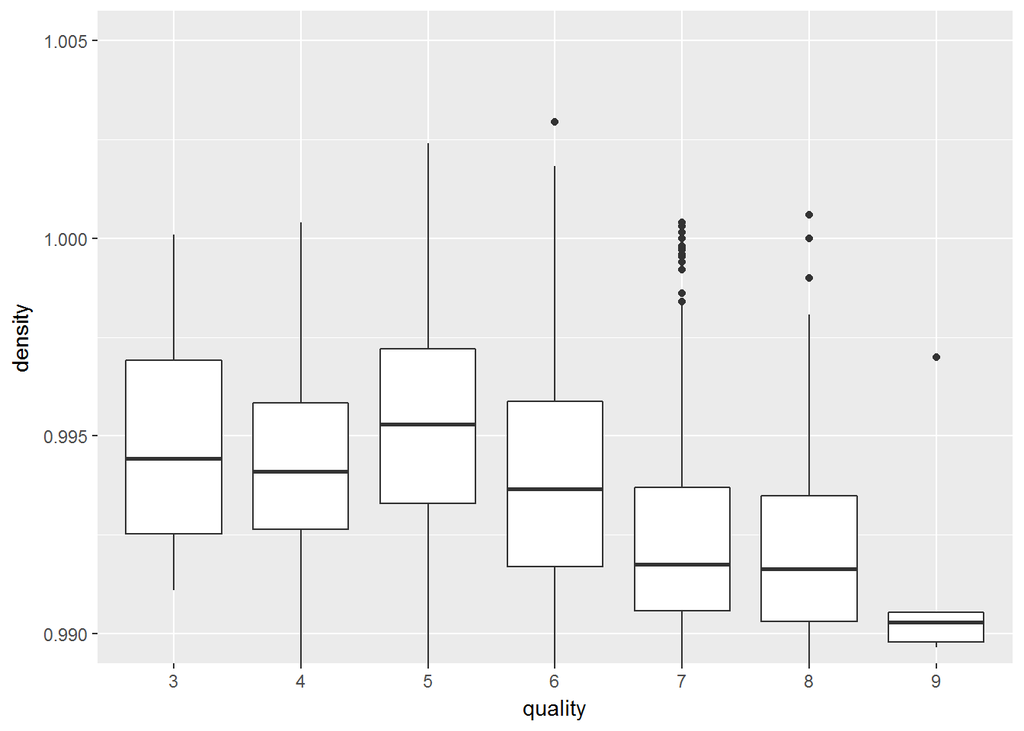

```
## $`3`
##    Min. 1st Qu.  Median    Mean 3rd Qu.    Max.
##  0.9911  0.9925  0.9944  0.9949  0.9969  1.0000
##
## $`4`
##    Min. 1st Qu.  Median    Mean 3rd Qu.    Max.
##  0.9892  0.9926  0.9941  0.9943  0.9958  1.0000
##
## $`5`
##    Min. 1st Qu.  Median    Mean 3rd Qu.    Max.
##  0.9872  0.9933  0.9953  0.9953  0.9972  1.0020
##
## $`6`
##    Min. 1st Qu.  Median    Mean 3rd Qu.    Max.
##  0.9876  0.9917  0.9937  0.9940  0.9959  1.0390
##
## $`7`
##    Min. 1st Qu.  Median    Mean 3rd Qu.    Max.
##  0.9871  0.9906  0.9918  0.9925  0.9937  1.0000
##
## $`8`
##    Min. 1st Qu.  Median    Mean 3rd Qu.    Max.
##  0.9871  0.9903  0.9916  0.9922  0.9935  1.0010
##
## $`9`
##    Min. 1st Qu.  Median    Mean 3rd Qu.    Max.
##  0.9896  0.9898  0.9903  0.9915  0.9906  0.9970
```

其次，从中位数观察密度与质量的关系，发现密度越低酒精质量越好，呈负相关关系。

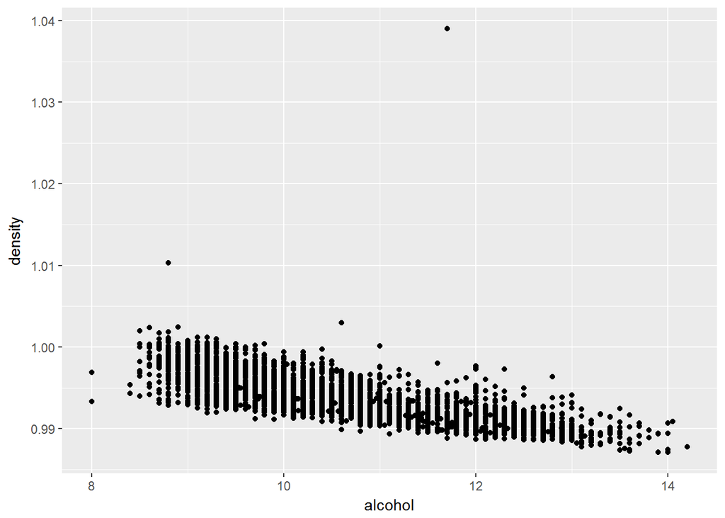

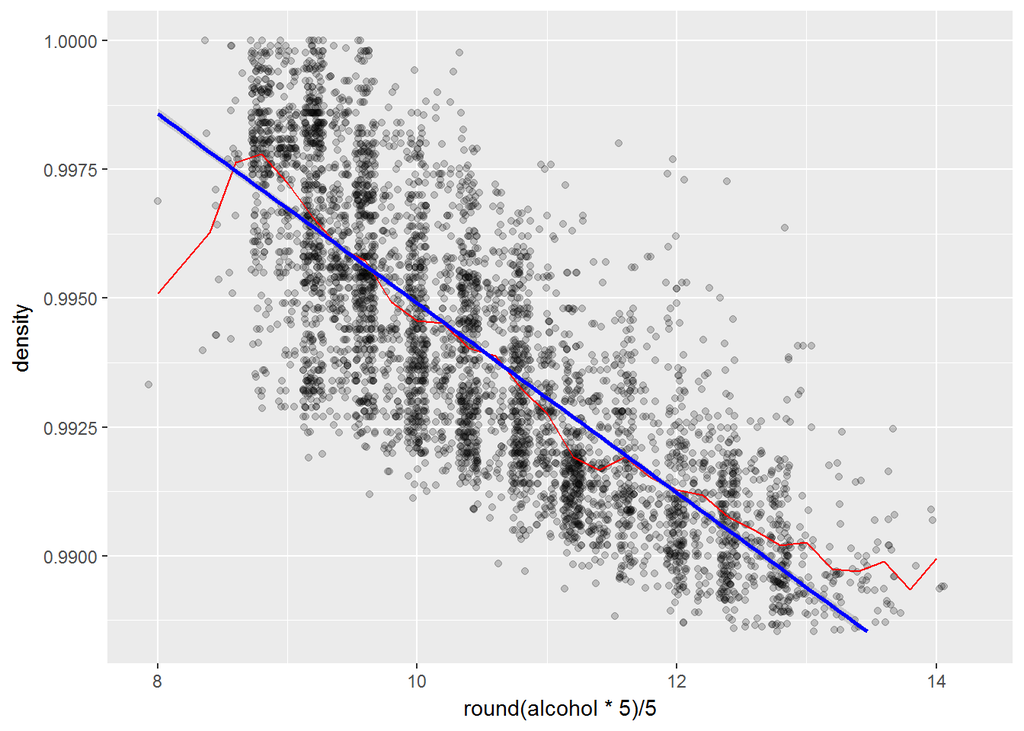

作图观察酒精度与密度的相关性，删掉异常值，改变透明度增加抖动并圆整，绘制密度平均线（红），回归线（蓝)。发现，随着酒精度的增加，密度是逐渐下降的，呈负相关的线性关系。

```
##
## Calls:
## m1: lm(formula = ww$density ~ ww$alcohol)
##
## =============================
##   (Intercept)      1.014***
##                   (0.000)
##   ww$alcohol      -0.002***
##                   (0.000)
## -----------------------------
##   R-squared            0.6
##   adj. R-squared       0.6
##   sigma                0.0
##   F                 7613.4
##   p                    0.0
##   Log-likelihood   23815.9
##   Deviance             0.0
##   AIC             -47625.8
##   BIC             -47606.3
##   N                 4898
## =============================
```

基于R^2值，酒精度解释了密度差异的60%。

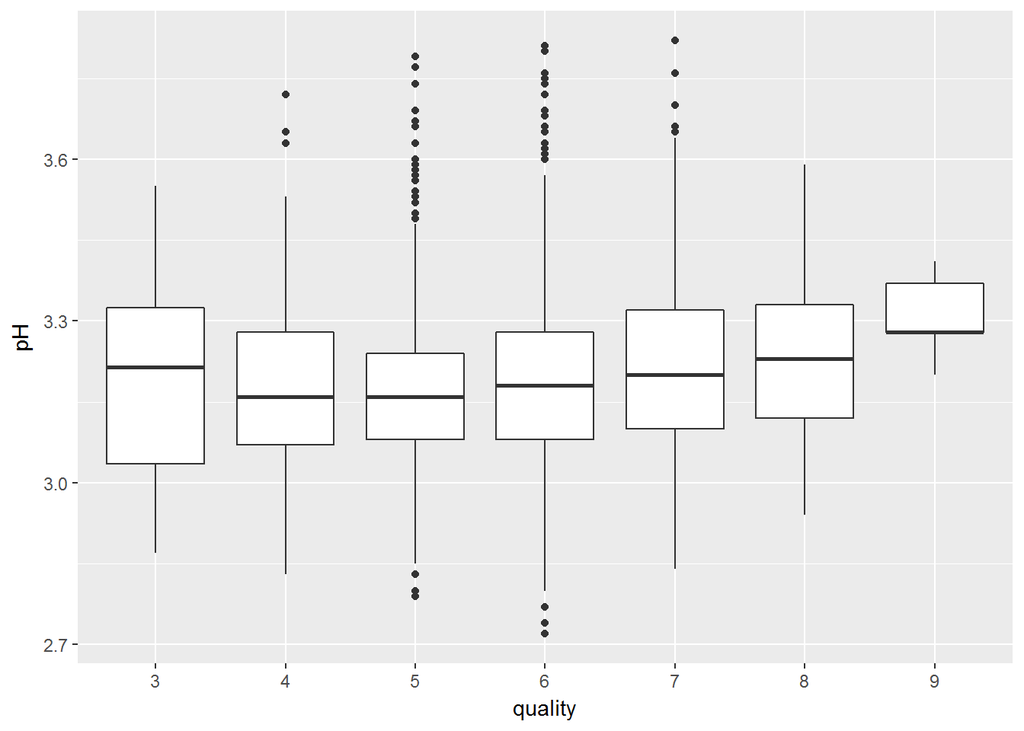

```
## $`3`
##    Min. 1st Qu.  Median    Mean 3rd Qu.    Max.
##   2.870   3.035   3.215   3.188   3.325   3.550
##
## $`4`
##    Min. 1st Qu.  Median    Mean 3rd Qu.    Max.
##   2.830   3.070   3.160   3.183   3.280   3.720
##
## $`5`
##    Min. 1st Qu.  Median    Mean 3rd Qu.    Max.
##   2.790   3.080   3.160   3.169   3.240   3.790
##
## $`6`
##    Min. 1st Qu.  Median    Mean 3rd Qu.    Max.
##   2.720   3.080   3.180   3.189   3.280   3.810
##
## $`7`
##    Min. 1st Qu.  Median    Mean 3rd Qu.    Max.
##   2.840   3.100   3.200   3.214   3.320   3.820
##
## $`8`
##    Min. 1st Qu.  Median    Mean 3rd Qu.    Max.
##   2.940   3.120   3.230   3.219   3.330   3.590
##
## $`9`
##    Min. 1st Qu.  Median    Mean 3rd Qu.    Max.
##   3.200   3.280   3.280   3.308   3.370   3.410
```

对于大部分的白葡萄酒中质量与pH的关系，从中位数能够观察解释的是pH增加即酸性降低，质量评价越好。

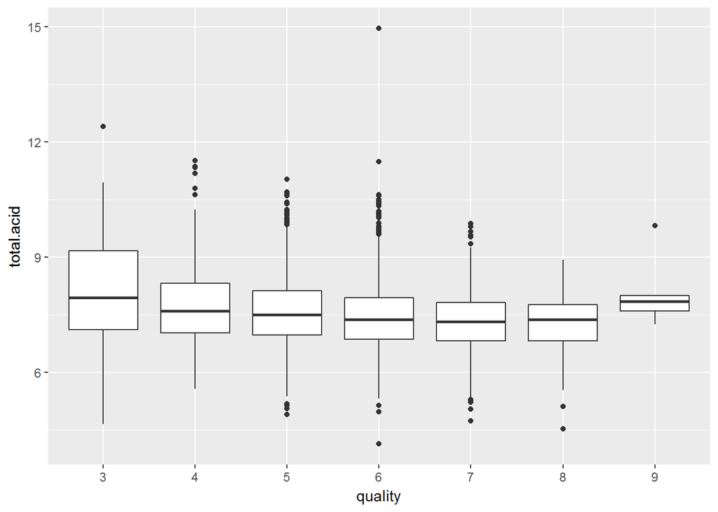

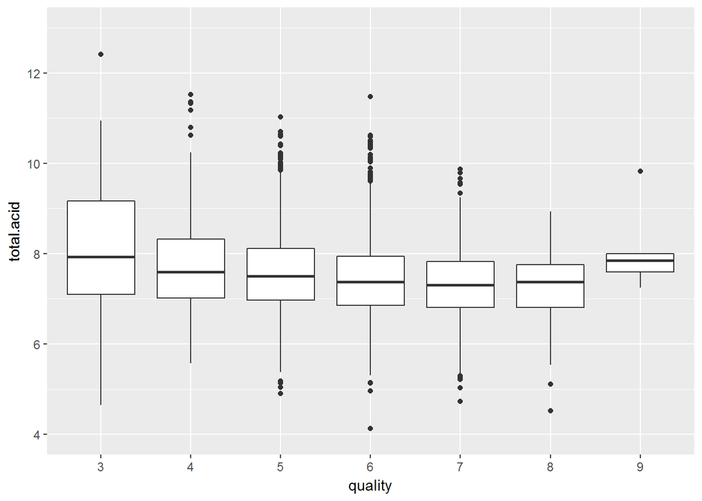

```
## $`3`
##    Min. 1st Qu.  Median    Mean 3rd Qu.    Max.
##   4.645   7.102   7.935   8.269   9.163  12.410
##
## $`4`
##    Min. 1st Qu.  Median    Mean 3rd Qu.    Max.
##   5.570   7.020   7.590   7.815   8.320  11.520
##
## $`5`
##    Min. 1st Qu.  Median    Mean 3rd Qu.    Max.
##   4.900   6.970   7.500   7.574   8.120  11.030
##
## $`6`
##    Min. 1st Qu.  Median    Mean 3rd Qu.    Max.
##   4.130   6.860   7.370   7.436   7.940  14.960
##
## $`7`
##    Min. 1st Qu.  Median    Mean 3rd Qu.    Max.
##   4.730   6.810   7.310   7.323   7.820   9.870
##
## $`8`
##    Min. 1st Qu.  Median    Mean 3rd Qu.    Max.
##   4.525   6.810   7.370   7.261   7.760   8.930
##
## $`9`
##    Min. 1st Qu.  Median    Mean 3rd Qu.    Max.
##   7.250   7.600   7.850   8.104   8.000   9.820
```

从创造的新变量总酸度的中位数来看，总酸度的变化带来的质量评价变化并不明显。

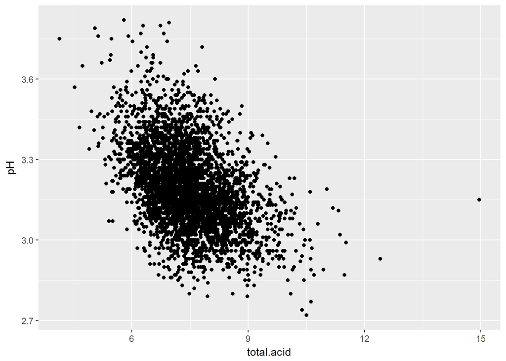

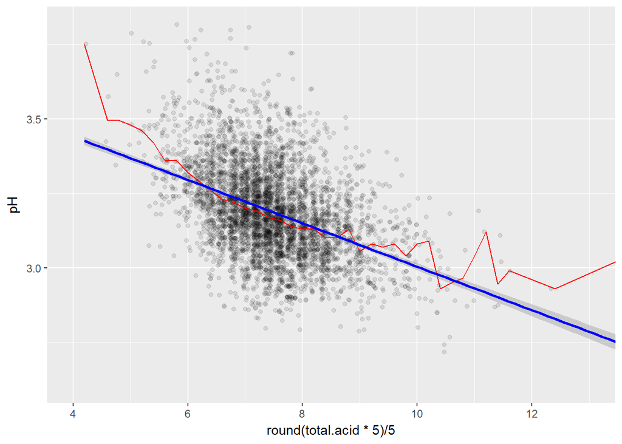

```
##
## Calls:
## m1: lm(formula = ww$total.acid ~ ww$pH)
##
## =============================
##   (Intercept)     15.541***
##                   (0.242)
##   ww$pH           -2.532***
##                   (0.076)
## -----------------------------
##   R-squared            0.2
##   adj. R-squared       0.2
##   sigma                0.8
##   F                 1114.8
##   p                    0.0
##   Log-likelihood   -5865.1
##   Deviance          3145.1
##   AIC              11736.2
##   BIC              11755.6
##   N                 4898
## =============================
```

增加抖动，透明度和改变图表限制让我们看到总酸度和pH之间的轻微相关性。但基于R^2值，总酸度仅解释了pH差异的20%，不够理想。

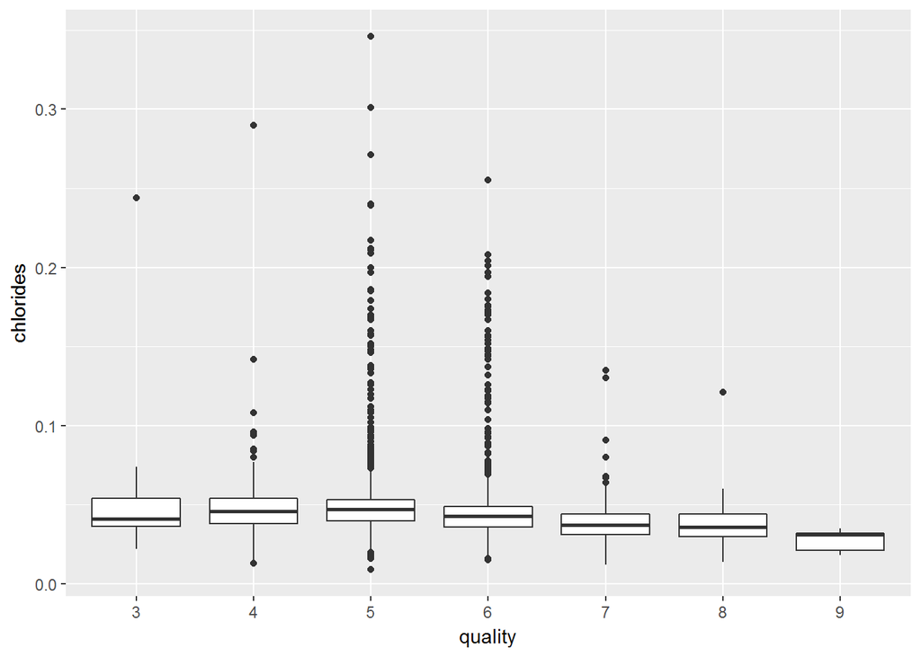

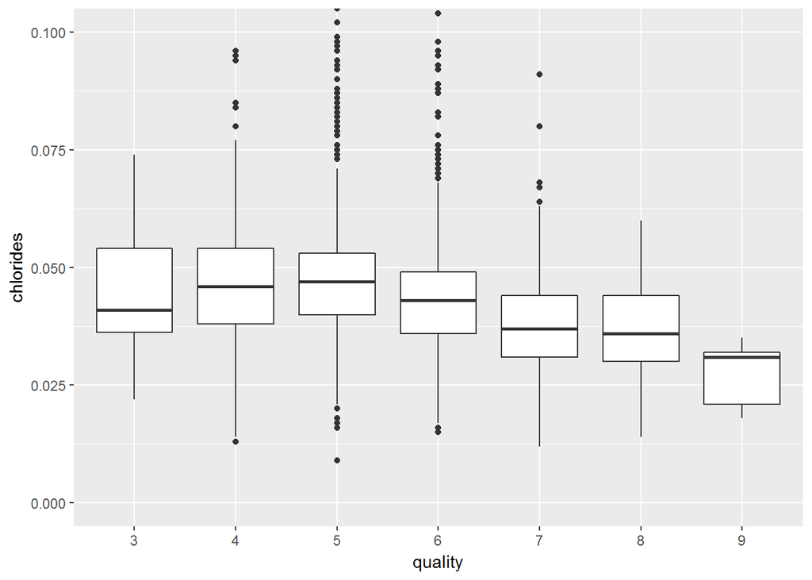

```
## $`3`
##    Min. 1st Qu.  Median    Mean 3rd Qu.    Max.
## 0.02200 0.03625 0.04100 0.05430 0.05400 0.24400
##
## $`4`
##    Min. 1st Qu.  Median    Mean 3rd Qu.    Max.
##  0.0130  0.0380  0.0460  0.0501  0.0540  0.2900
##
## $`5`
##    Min. 1st Qu.  Median    Mean 3rd Qu.    Max.
## 0.00900 0.04000 0.04700 0.05155 0.05300 0.34600
##
## $`6`
##    Min. 1st Qu.  Median    Mean 3rd Qu.    Max.
## 0.01500 0.03600 0.04300 0.04522 0.04900 0.25500
##
## $`7`
##    Min. 1st Qu.  Median    Mean 3rd Qu.    Max.
## 0.01200 0.03100 0.03700 0.03819 0.04400 0.13500
##
## $`8`
##    Min. 1st Qu.  Median    Mean 3rd Qu.    Max.
## 0.01400 0.03000 0.03600 0.03831 0.04400 0.12100
##
## $`9`
##    Min. 1st Qu.  Median    Mean 3rd Qu.    Max.
##  0.0180  0.0210  0.0310  0.0274  0.0320  0.0350
```

从中位数来看，箱线图显示质量评价与氯化物的相关关系也并不明显。

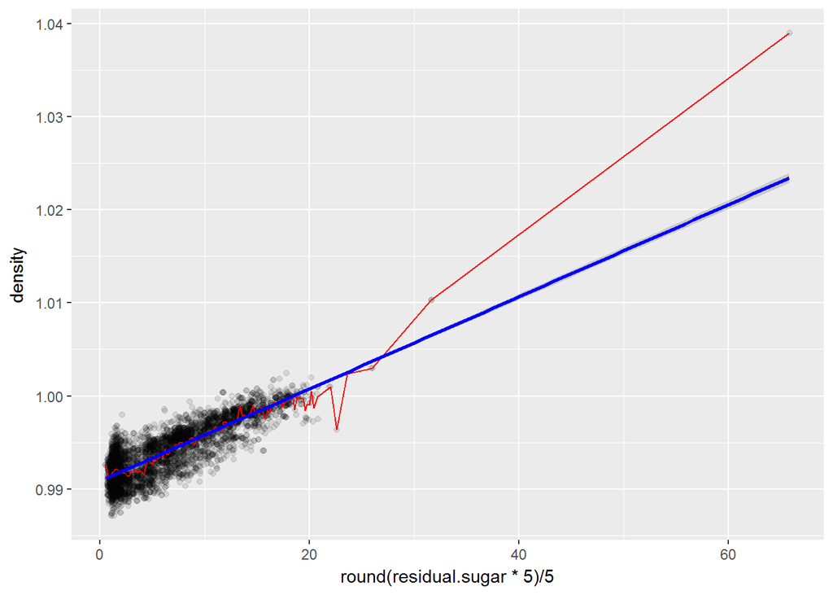

```
##
## Calls:
## m1: lm(formula = ww$residual.sugar ~ ww$density)
##
## ================================
##   (Intercept)     -1407.852***
##                     (13.110)
##   ww$density       1422.741***
##                     (13.189)
## --------------------------------
##   R-squared              0.7
##   adj. R-squared         0.7
##   sigma                  2.8
##   F                  11637.0
##   p                      0.0
##   Log-likelihood    -11922.3
##   Deviance           37306.9
##   AIC                23850.6
##   BIC                23870.1
##   N                   4898
## ================================
```

基于R^2值，残糖仅解释了密度差异的70%，残糖含量与密度呈高度的正相关关系。

## 双因素小结

### 谈谈你在这部分调查中看到的一些关系。感兴趣的功能与数据集中的其他功能有何不同？

第二，对于大部分的白葡萄酒中质量与pH的关系，从中位数能够观察解释的是pH增加即酸性降低，质量评价越好。而从创造的新变量总酸度的中位数来看，总酸度的变化带来的质量评价变化并不明显。并且对于酸度与pH，基于R^2值，总酸度仅解释了pH差异的20%，不够理想。

第三，氯化物等其他因素与质量评价相关性低，将不纳入分析范围。

### 最强的关系是什么？

白葡萄酒的质量与酒精度呈正相关。